# IS605_HW9

Daina Bouquin

April 3, 2016

```r
library(ggplot2)
```

Week 9 - Central Limit Theorem

##### 1. First write a function that will produce a sample of random variables that are distributed as follows:

$$f(x) = x, 0 ≤ x ≤ 1$$
$$f(x) = 2 − x, 1 < x ≤ 2$$

```r
# will be used with sample()
q1 <- function(x){
    if(0<=x && x<=2){
        if(x<=1){
            return(x)
        } else {
            return(2-x)
        }
    }
}

# need to create a large vector of values between 0 and 2
x <- seq(from=0, to=2, length.out=1000)

# create vector of probs for sampling using sapply()
x_prob <- sapply(x, q1)

# create a sample using sample()
s1 <- data.frame(X = sample(x, 1000, replace=TRUE, prob=x_prob))
head(s1,10)
```

```
##             X
## 1  1.61361361
## 2  0.07007007
## 3  0.68868869
## 4  1.10910911
## 5  0.19419419
## 6  0.68068068
## 7  1.34734735
## 8  1.78378378
## 9  1.34134134
## 10 0.85685686
```

##### 2. Now, write a function that will produce a sample of random variable that is distributed as follows:

$$f(x) = 1 − x, 0 ≤ x ≤ 1$$
$$f(x) = x − 1, 1 < x ≤ 2$$

```r
# Use same technique as above with sample()
q2 <- function(x) {
  r <- 0 #start
  if (0<=x && x<=2) {
    if (x<=1) {
      r <- (1-x)
    }
    else {
      r <- (x-1)
    }
  }
  return (r)
}

# create a large vector of values between 0 and 2
x <- seq(from=0, to=2, length.out=1000)

# create vector of probs for sampling using sapply()
x_prob2 <- sapply(x, q2)

# create a sample using sample()
s2 <- data.frame(X = sample(x, 1000, replace=TRUE, prob=x_prob2))
head(s2,10)
```

```
##            X
## 1  1.7737738
## 2  1.7077077
## 3  0.3383383
## 4  0.3883884
## 5  0.2122122
## 6  1.9799800
## 7  1.5795796
## 8  1.6556557
## 9  1.9099099
## 10 0.4064064
```

#### 3. Draw 1000 samples (call your function 1000 times each) from each of the above two distributions and plot the resulting histograms. You should have one histogram for each PDF. See that it matches your understanding of these PDFs.

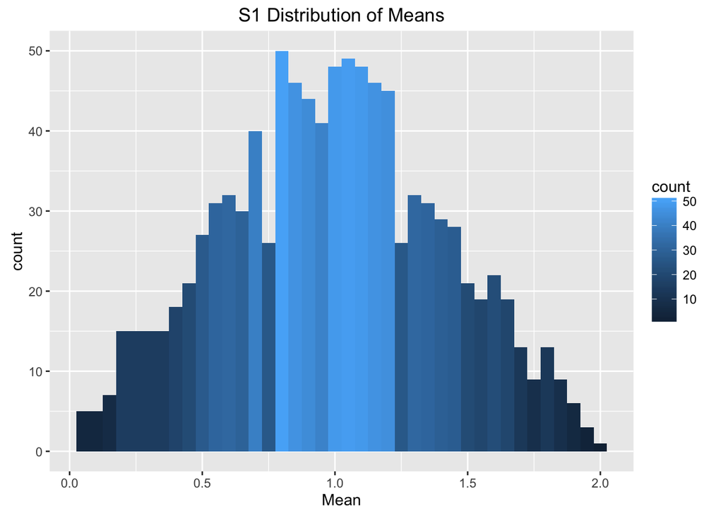

```r
# Plot s1 and s2
ggplot(s1, aes(s1$X)) +
  geom_histogram(binwidth=.05,  aes(fill=..count..)) +
  xlab("Mean") +
  ggtitle("S1 Distribution of Means")
```

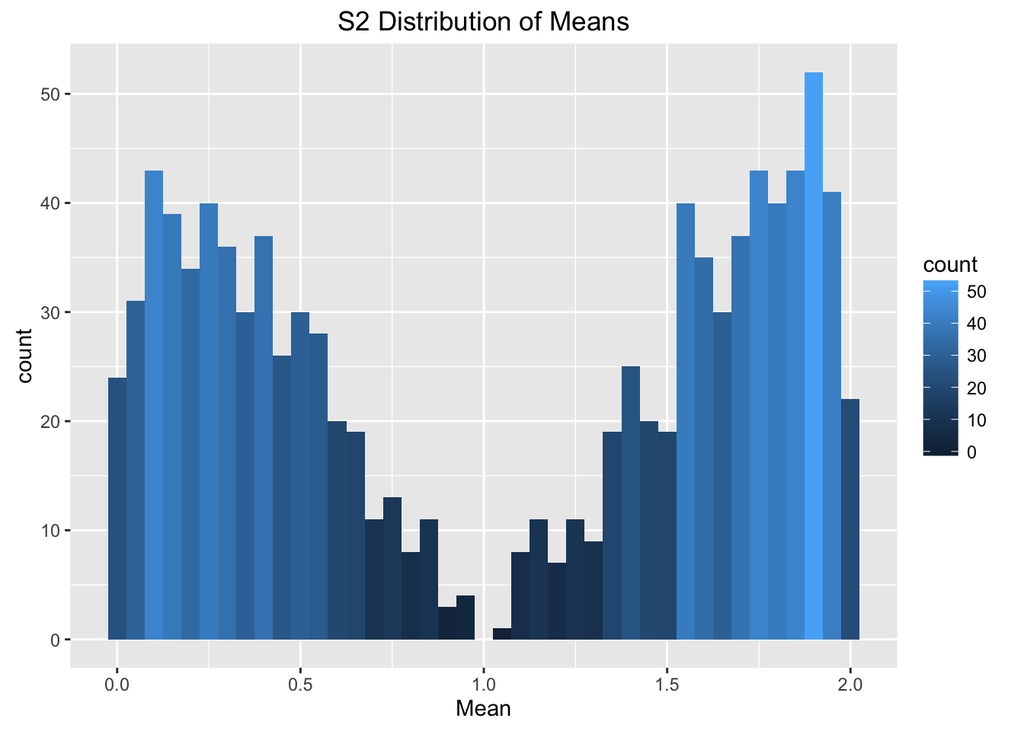

```r
ggplot(s2, aes(s2$X)) +
  geom_histogram(binwidth=.05,  aes(fill=..count..)) +
  xlab("Mean") +
  ggtitle("S2 Distribution of Means")
```

#### 4. Now, write a program that will take a sample set size n as a parameter and the PDF as the second parameter, and perform 1000 iterations where it samples from the PDF, each time taking n samples and computes the mean of these n samples. It then plots a histogram of these 1000 means that it computes.

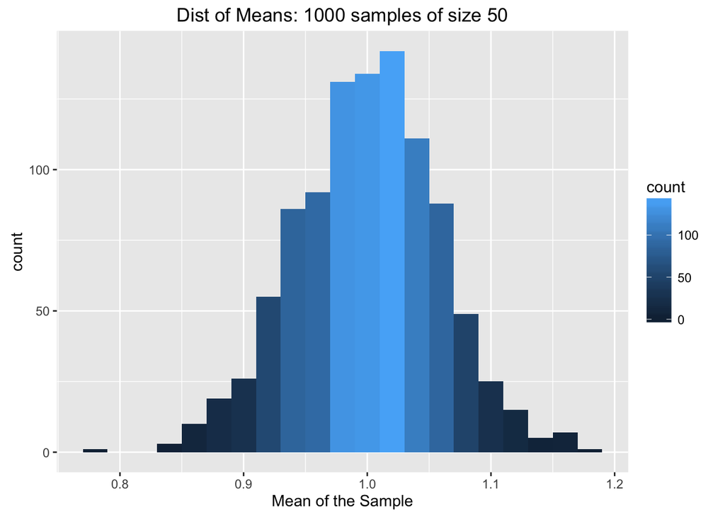

```r
dist_means <- function(n, pdf) {
  x <- seq(0,2, by=0.01)
  x_prob3 <- sapply(x, pdf)
  means <- c() # empty
  #1000 samples
  for(i in 1:1000) {
    s <-  sample(x,n,replace=TRUE, prob=x_prob3)
    means <- c(means,mean(s))
  }
  # convert to dataframe for plotting
  means_df <- data.frame(means)

  # Create the plot using the df
  ggplot(means_df, aes(means)) +
    geom_histogram(binwidth=.02, aes(fill=..count..)) +
    xlab("Mean of the Sample") +
    ggtitle(paste("Dist of Means: 1000 samples of size", n))
}

# Try the plotting functions with sample size 50
# First PDF
dist_means(50, q1)
```

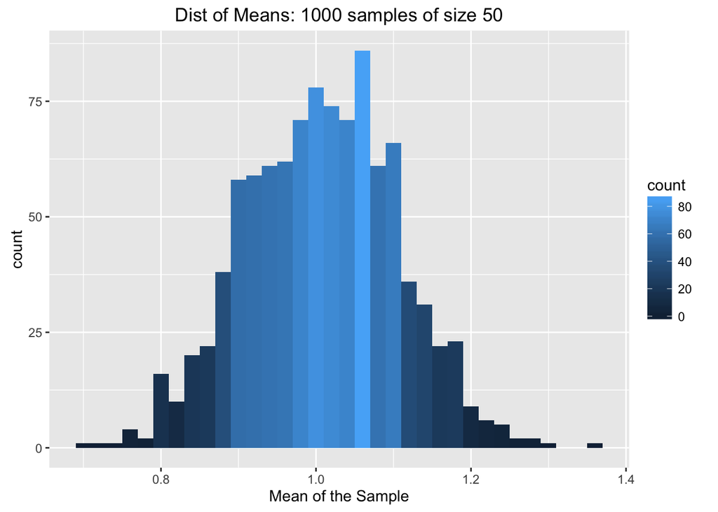

```r
# Second PDF
dist_means(50, q2)
```

#### 5. Verify that as you set n to something like 10 or 20, each of the two PDFs produce normally distributed mean of samples, empirically verifying the Central Limit Theorem.

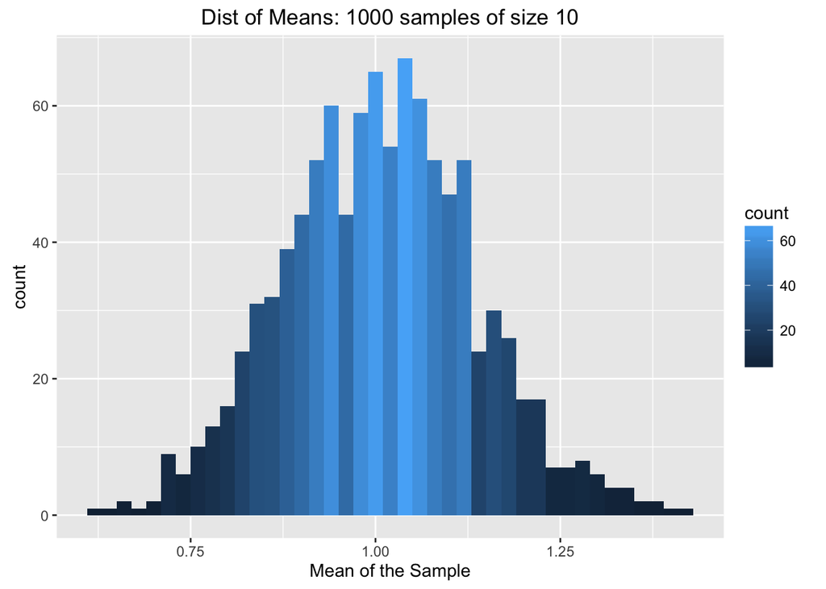

```r
# n = 10
dist_means(10, q1)
```

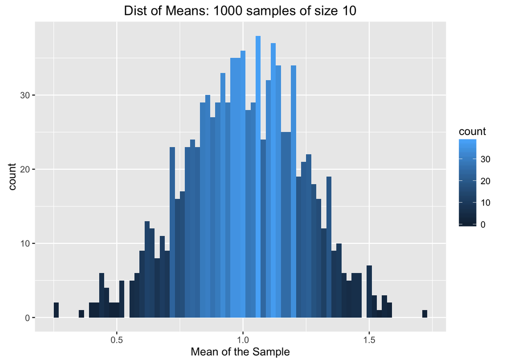

```r
dist_means(10, q2)
```

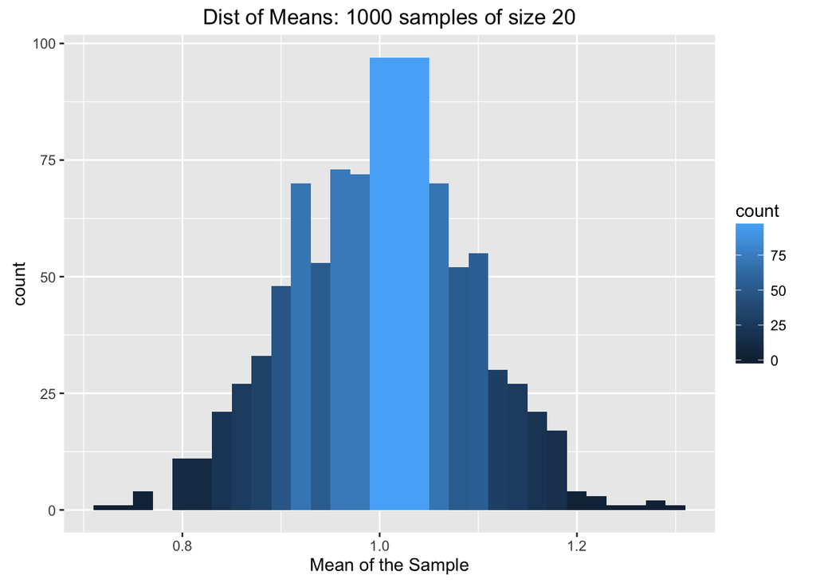

```r
# n = 20
dist_means(20, q1)
```

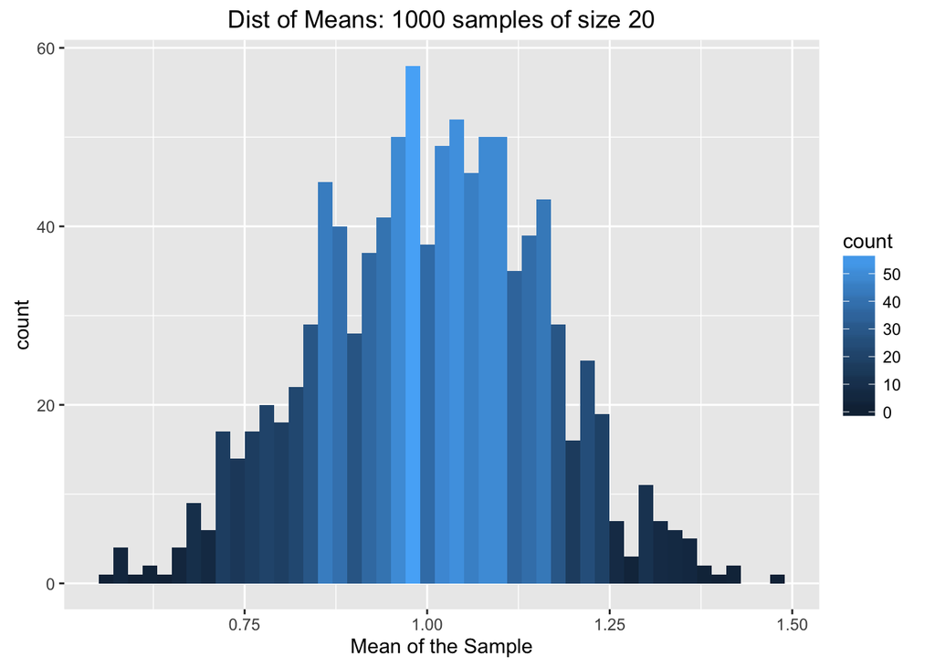

```r
dist_means(20, q2)
```

```r
# You can see from the plots that that the distribution of the sample means create a general "bell shaped" curve near the mean of the distribution from the prompt.
```